# Best prices

Center of statistic

30/11/2020

## Анализ стоимости недвижимости

## Первоначальная модель

В этой модели содержатся все факторы, которые потенциально могут оказать влияние на стоимость квартиры.

```
##
## Call:
## lm(formula = medv ~ crim + zn + indus + chas + nox + rm + age +
##     dis + rad + tax + ptratio + black, data = df)
##
## Residuals:
##    Min     1Q Median     3Q    Max
## -1.791 -0.285 -0.090  0.203  3.939
##
## Coefficients:
##              Estimate Std. Error t value Pr(>|t|)
## (Intercept) -1.12e-16   2.53e-02    0.00  1.00000
## crim        -1.50e-01   3.35e-02   -4.47  9.8e-06 ***
## zn           9.86e-02   3.83e-02    2.57  0.01039 *
## indus       -2.08e-02   5.04e-02   -0.41  0.67972
## chas         8.88e-02   2.62e-02    3.39  0.00075 ***
## nox         -2.58e-01   5.29e-02   -4.88  1.5e-06 ***
## rm           4.68e-01   2.97e-02   15.73  < 2e-16 ***
## age         -1.41e-01   4.19e-02   -3.36  0.00085 ***
## dis         -3.56e-01   5.03e-02   -7.08  5.1e-12 ***
## rad          2.67e-01   6.92e-02    3.85  0.00013 ***
## tax         -2.15e-01   7.60e-02   -2.83  0.00481 **
## ptratio     -2.39e-01   3.39e-02   -7.04  6.5e-12 ***
## black        1.35e-01   2.90e-02    4.66  4.1e-06 ***
## ---
## Signif. codes:  0 '***' 0.001 '**' 0.01 '*' 0.05 '.' 0.1 ' ' 1
##
## Residual standard error: 0.569 on 493 degrees of freedom
## Multiple R-squared:  0.684,  Adjusted R-squared:  0.677
## F-statistic:   89 on 12 and 493 DF,  p-value: <2e-16
```

Эта модель учитывает все предикторы, но в ней имеется ряд проблем.

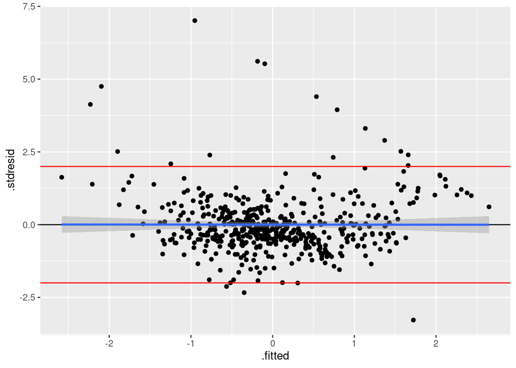

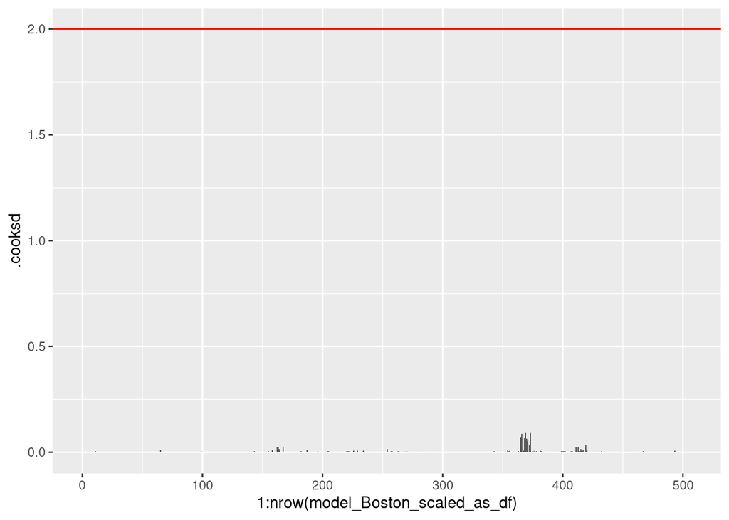

График расстояний Кука представляет удовлетворительный результат. На нём не обнаруживается причин для беспокойства.

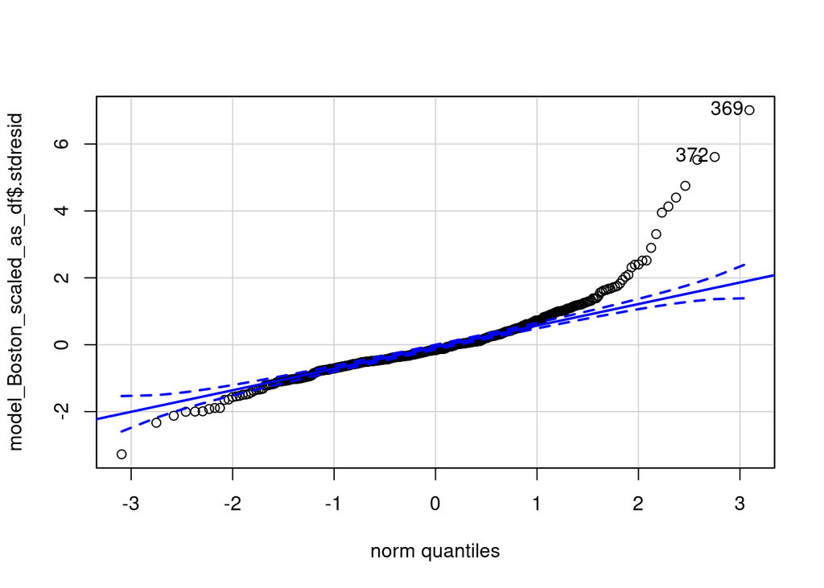

```
## [1] 369 372
```

Квантильный график показывает на очень серьёзные отклонения от ожидаемых значений в правой части графика. Это указывает на возможное серьёзное отклонение от нормального распределения остатков.

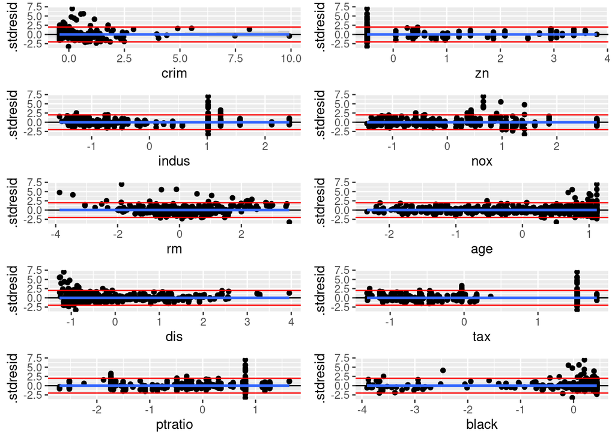

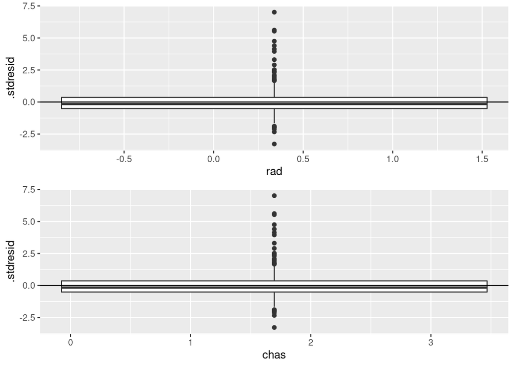

Анализ отдельных предикторов, включённых в модель, указывает на явные проблемы с предикторами. Предикторы zn, indus, tax, ptratio имеют очень выраженные палочные паттерны из определённых наблюдений. Судя по всему это ряд взаимосвязанных наблюдений, которые оказываются существенное влияние на предсказание модели. Эти же наблюдения формируют серию убывающих по значению наблюдений на графике остатков. Я предполагаю, что эти же наблюдения являются выбросами на графиках с боксплотами.

#### Взаимосвязь предикторов друг с другом.

```
##    crim      zn   indus    chas     nox      rm     age     dis     rad     tax
##  1.7504  2.2923  3.9684  1.0702  4.3729  1.3804  2.7400  3.9501  7.4750  9.0064
## ptratio   black
##  1.7954  1.3161
```

Также проведя тест на мультиколлинеарность мы можем обнаружить, что некоторые предикторы имеют чётко выраженные корреляции друг с другом. Так как наличие коллинеарных предикторов может оказать существенное влияние на модель, рекомендуется отказаться от использования текущей модели. В ней имеется большое количество коллинеарных предикторов.

## Улучшение модели

Модель можно улучшить для более точного предсказания.

Первым делом уберём предиктор indus, его p-value > 0.05. Он не оказывает существенного влияния на предсказываемое значение переменной medv.

```r
mod_1 <- update(model_Boston_scaled , .~. - indus)
```

После этого уберём предикторы, значение VIF которых больше 2.

```r
vif(mod_1)
```

```
##    crim      zn    chas     nox      rm     age     dis     rad     tax ptratio
##  1.7492  2.2681  1.0597  4.0527  1.3462  2.7377  3.7777  6.9029  7.2778  1.7632
##   black
##  1.3133
```

Начнём с предиктора tax.

```r
mod_2 <- update(mod_1, .~. - tax)
vif(mod_2)
```

```
##    crim      zn    chas     nox      rm     age     dis     rad ptratio   black
##  1.7478  2.1785  1.0518  3.8525  1.3091  2.7326  3.7519  2.7898  1.7236  1.3101
```

Удалим предиктор nox.

```r
mod_3 <- update(mod_2, .~. - nox)
vif(mod_3)
```

```
##    crim      zn    chas      rm     age     dis     rad ptratio   black
##  1.7399  2.1777  1.0501  1.2247  2.4044  3.1900  2.3454  1.5863  1.2921
```

Удалим предиктор dis

```r
mod_4 <- update(mod_3, .~. - dis)
vif(mod_4)
```

```
##    crim      zn    chas      rm     age     rad ptratio   black
##  1.7263  1.6812  1.0471  1.2215  1.7588  2.2363  1.5294  1.2907
```

Последний предиктор со значение VIF > 2 это предиктор rad. Удалим его из модели

```r
mod_5 <- update(mod_4, .~. - rad)
vif(mod_5)
```

```
##    crim      zn    chas      rm     age ptratio   black
##  1.3426  1.6804  1.0437  1.2167  1.6682  1.3455  1.2099
```

### Отбор предикторов по значимости

Мы избавились от предикторов с мультиколлинеарностью. Теперь произведём отбор предикторов по значимости.

```r
drop1(mod_5, test = "F")
```

```
## Single term deletions
##
## Model:
## medv ~ crim + zn + chas + rm + age + ptratio + black
##         Df Sum of Sq RSS  AIC F value  Pr(>F)
## <none>               183 -498
## crim     1       3.8 187 -489   10.38 0.00136 **
## zn       1       0.0 183 -500    0.05 0.82206
## chas     1       4.6 188 -487   12.42 0.00046 ***
## rm       1     120.9 304 -243  328.33 < 2e-16 ***
## age      1       4.9 188 -486   13.23 0.00030 ***
## ptratio  1      17.9 201 -453   48.64 9.8e-12 ***
## black    1       9.2 193 -475   25.08 7.6e-07 ***
## ---
## Signif. codes:  0 '***' 0.001 '**' 0.01 '*' 0.05 '.' 0.1 ' ' 1
```

```r
mod_6 <- update(mod_5, .~. - zn)
mod_6 <- update(mod_6, .~. - zn)
```

Предиктор zn оказался незначимым и мы удаляем его из модели.

[output not shown]

Все остальные предикторы оказались значимыми. Они важны для модели.

### Диагностика новой модели

Проведём диагностику, полученной модели

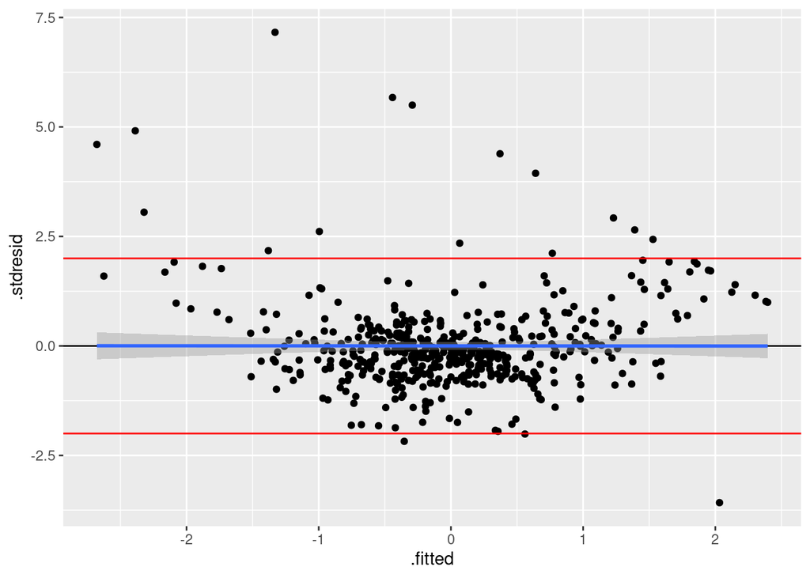

Вам может показаться, что этот график остатков похож на предыдущи. Это так.

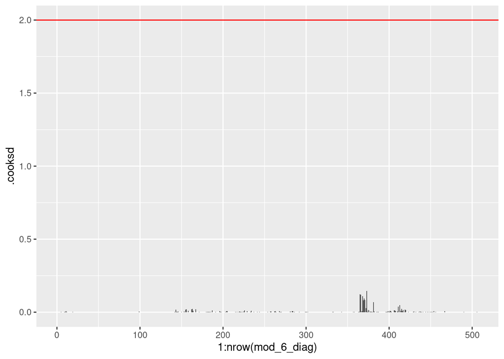

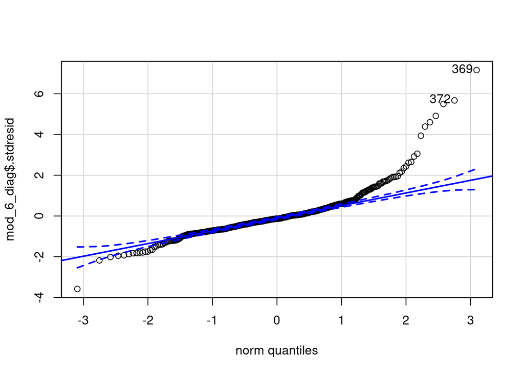

```
## [1] 369 372
```

## Предсказания модели

```
##
## Call:
## lm(formula = medv ~ crim + chas + rm + age + ptratio + black,
##     data = df)
##
## Residuals:
##    Min     1Q Median     3Q    Max
## -2.100 -0.319 -0.081  0.186  4.317
##
## Coefficients:
##              Estimate Std. Error t value Pr(>|t|)
## (Intercept) -2.75e-16   2.69e-02    0.00  1.00000
## crim        -1.01e-01   3.11e-02   -3.25  0.00121 **
## chas         9.75e-02   2.75e-02    3.54  0.00043 ***
## rm           5.39e-01   2.94e-02   18.30  < 2e-16 ***
## age         -1.23e-01   3.02e-02   -4.07  5.5e-05 ***
## ptratio     -2.17e-01   3.01e-02   -7.19  2.4e-12 ***
## black        1.49e-01   2.97e-02    5.01  7.6e-07 ***
## ---
## Signif. codes:  0 '***' 0.001 '**' 0.01 '*' 0.05 '.' 0.1 ' ' 1
##
## Residual standard error: 0.606 on 499 degrees of freedom
## Multiple R-squared:  0.637,  Adjusted R-squared:  0.633
## F-statistic:  146 on 6 and 499 DF,  p-value: <2e-16
```

Наша итоговая модель говорит, что наибольшее влияние на стоимость квартиры оказывается переменная rm. Остальные переменные оказывают меньшее значение. Поэтому предсказание мы будем строить по этому предиктору.

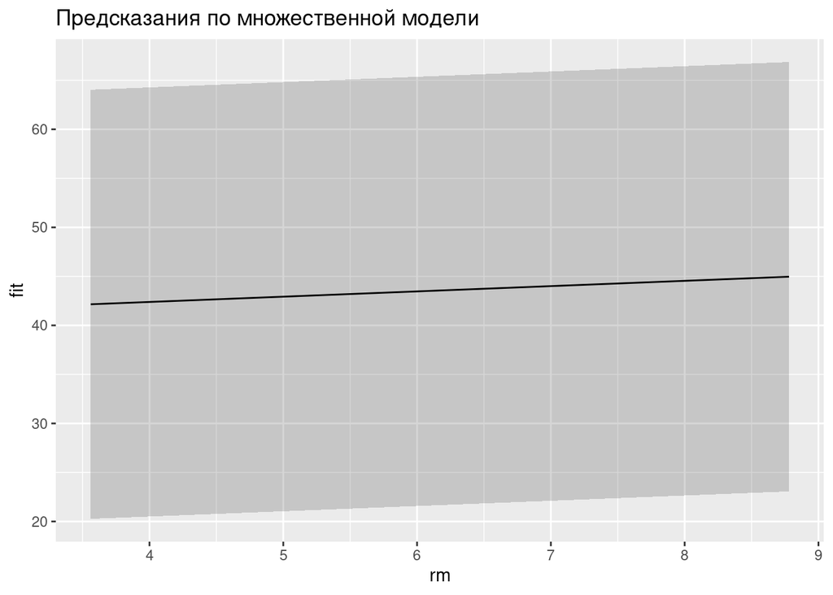

## Окончательные рекомендации

Как вы можете видеть с увеличением количества комнат возрастает цена. Повышение среднего возраста жильцов, высокий уровень преступности же ведут к снижению стоимости жилья.